# Pracatical Machine Learning Project

## Executive Summary

Using devices such as Jawbone Up, Nike FuelBand, and Fitbit it is now possible to collect a large amount of data about personal activity relatively inexpensively. These type of devices are part of the quantified self movement - a group of enthusiasts who take measurements about themselves regularly to improve their health, to find patterns in their behavior, or because they are tech geeks. One thing that people regularly do is quantify how much of a particular activity they do, but they rarely quantify how well they do it. The aim of this report was to use data from accelerometers placed on the belt, forearm, arm, and dumbell of six participants to predict how well they were doing the exercise in terms of the classification in the data.

```r
library(caret)
```

```r
library(corrplot)
library(kernlab)
library(knitr)
library(randomForest)
opts_chunk$set(cache = FALSE)
```

```r
##Load the training data into R.

## The required datasets are downloaded from the locations specified for both training and testing purposes

## read the csv file for training
## There are lot of values like "NA" in the dataset which cannot be analyzed. So we need to remove those records.
##Also need to remove the header rows also from the dataset.

training_data_initial <- read.csv("pml-training.csv", na.strings= c("NA",""," "))
training_data_NA<- apply(training_data_initial, 2, function(x) {sum(is.na(x))})
training_data <- training_data_initial[,which(training_data_NA == 0)]

##removing the header rows to remove the descriptor portion

training_data <- training_data[8:length(training_data)]
```

Examining the target variable to see its distribution using qplot.

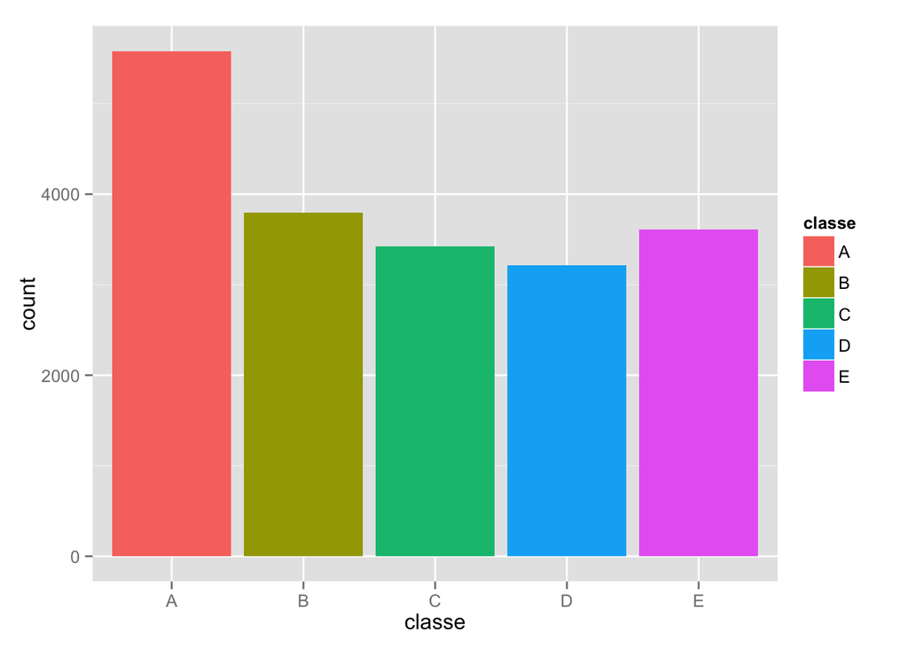

```r
# Plot
qplot(classe, data = training_data, fill = classe)
```

## Creating a model

```r
# split the cleaned testing data into training and cross validation
inTrain <- createDataPartition(y = training_data$classe, p = 0.7, list = FALSE)
training <- training_data[inTrain, ]
crossval <- training_data[-inTrain, ]
```

A random forest model was selected to predict the classification because it has methods for balancing error in class population unbalanced data sets. The correlation between any two trees in the forest increases the forest error rate. Therefore, a correllation plot was produced in order to see how strong the variables relationships are with each other.

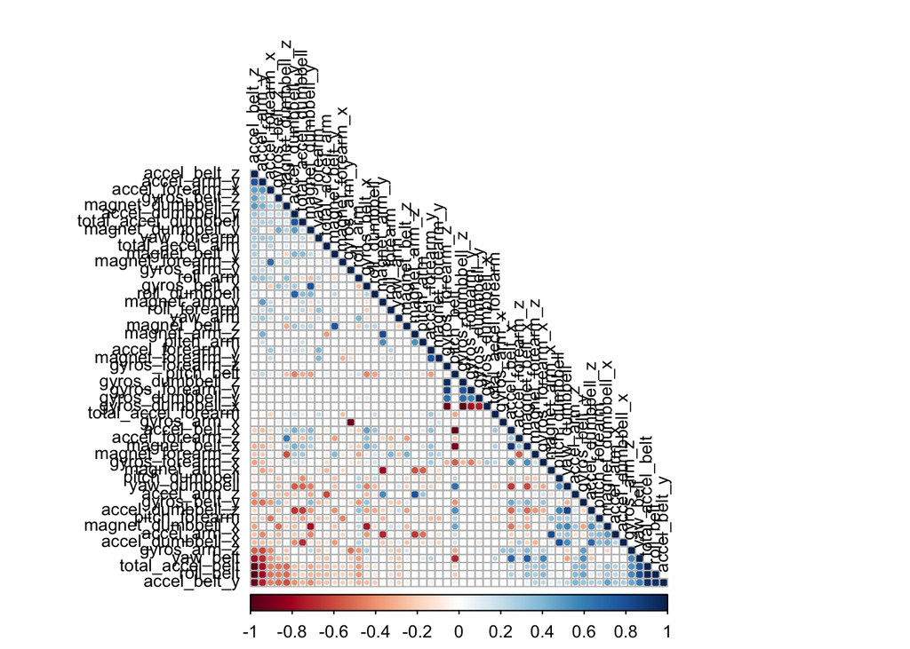

```r
# plot a correlation matrix

correlMatrix <- cor(training[, -length(training)])
corrplot(correlMatrix, order = "FPC", method = "circle", type = "lower", tl.cex = 0.8,  tl.col = rgb(0, 0, 0))
```

In this plot the red and blue colours indicate a highly negative and positive relationship respectively between the variables.

Then a model was fitted with the outcome set to the training class and all the other variables used to predict.

```r
# fit a model to predict the classe using everything else as a predictor
model <- randomForest(classe ~ ., data = training)
model
```

```
##
## Call:
##  randomForest(formula = classe ~ ., data = training)
##                Type of random forest: classification
##                      Number of trees: 500
## No. of variables tried at each split: 7
##
##         OOB estimate of  error rate: 0.47%
## Confusion matrix:
##      A    B    C    D    E  class.error
## A 3903    2    0    0    1 0.0007680492
## B   16 2636    6    0    0 0.0082768999
## C    0   14 2380    2    0 0.0066777963
## D    0    0   16 2234    2 0.0079928952
## E    0    0    1    5 2519 0.0023762376
```

As the above results show, the resulting predictor has a low OOB (out-of-bag) error estimate. The confusion matrix for the training set indicates that the predictor is accurate on that set.

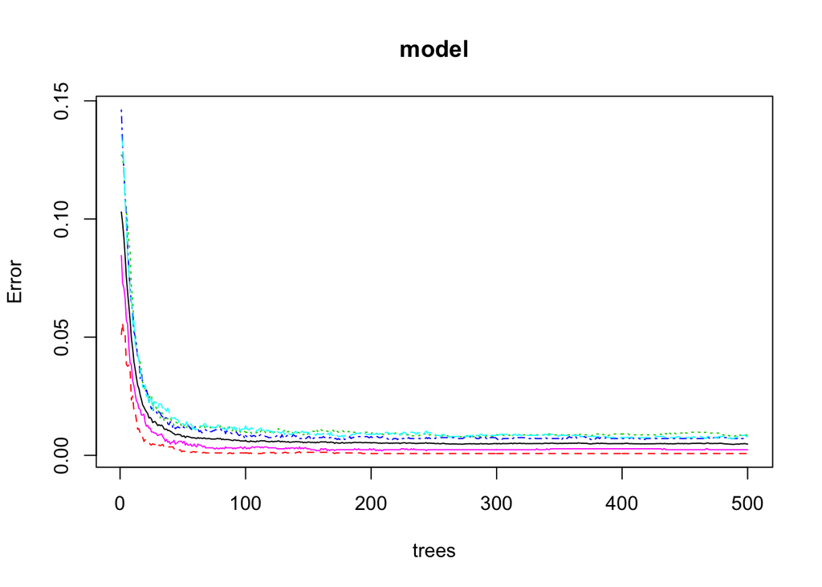

```r
plot(model)
```

## Cross-validation

The model was then used to classify the remaining 30% of data. The results were placed in a confusion matrix along with the actual classifications in order to determine the accuracy of the model.

```r
# crossvalidate the model using the remaining 30% of data
predictCrossVal <- predict(model, crossval)
confusionMatrix(crossval$classe, predictCrossVal)
```

```
## Confusion Matrix and Statistics
##
##           Reference
## Prediction    A    B    C    D    E
##          A 1672    0    2    0    0
##          B    3 1136    0    0    0
##          C    0   11 1014    1    0
##          D    0    0   16  947    1
##          E    0    0    0    1 1081
##
## Overall Statistics
##
##                Accuracy : 0.9941
##                  95% CI : (0.9917, 0.9959)
##     No Information Rate : 0.2846
##     P-Value [Acc > NIR] : < 2.2e-16
##
##                   Kappa : 0.9925
##  Mcnemar's Test P-Value : NA
##
## Statistics by Class:
##
##                      Class: A Class: B Class: C Class: D Class: E
## Sensitivity            0.9982   0.9904   0.9826   0.9979   0.9991
## Specificity            0.9995   0.9994   0.9975   0.9966   0.9998
## Pos Pred Value         0.9988   0.9974   0.9883   0.9824   0.9991
## Neg Pred Value         0.9993   0.9977   0.9963   0.9996   0.9998
## Prevalence             0.2846   0.1949   0.1754   0.1613   0.1839
## Detection Rate         0.2841   0.1930   0.1723   0.1609   0.1837
## Detection Prevalence   0.2845   0.1935   0.1743   0.1638   0.1839
## Balanced Accuracy      0.9989   0.9949   0.9900   0.9972   0.9994
```

Predictions

A separate data set(pml-testing.csv) was then loaded into R and cleaned in the same manner as before by removing the columns having values ‘NA’ and cleaning the header rows. The model is then used to predict the classifications of the 20 results of this new data.

```r
# apply the same treatment to the final testing data
testing_data_initial <- read.csv("pml-testing.csv", na.strings= c("NA",""," "))
testing_data_NA <- apply(testing_data_initial, 2, function(x) {sum(is.na(x))})
testing_data <- testing_data_initial[,which(testing_data_NA == 0)]
testing_data <- testing_data[8:length(testing_data)]

# predict the classes of the test set
predictTest <- predict(model,testing_data)
predictTest
```

```
##  1  2  3  4  5  6  7  8  9 10 11 12 13 14 15 16 17 18 19 20
##  B  A  B  A  A  E  D  B  A  A  B  C  B  A  E  E  A  B  B  B
## Levels: A B C D E
```

## Conclusions

From the available parameters from different sensors it is possible to accurately predict how well a person is preforming an excercise using a relatively simple model.